# 量的調査（第8回）

Author

藤原翔

Published

January 10, 2024

# 1 パネルデータ分析の基礎

## 1.1 目的

- パネルデータを用いた様々な分析手法について理解し，今後の深い学習のためのきっかけとする．
- Rでロングデータを作成し，固定効果モデルによる分析をできるようにする．

## 1.2 パネルデータとは

- 同一個人に対しての追跡調査（パネル調査）から得られたデータ
- データはワイド形式で管理されることが多いが，分析によってはロング形式に変換する必要がある．
- 変数は時間によって変化しない変数（time-invariant variable）と，時間によって変化する変数（time-varying variable）がある．

## 1.3 ワイド形式

- 時間によって変化しない変数
  - `ID`, `Gender`, `Z`
- 時間によって変化する変数
  - `Y1,Y2,Y3`，`X1,X2,X3`，`C1,C2,C3`

```
# A tibble: 10 × 12
   ID    Gender    Y1    Y2    Y3    X1    X2    X3    C1    C2    C3     Z
   <chr> <chr>  <int> <int> <int> <int> <int> <int> <dbl> <dbl> <dbl> <dbl>
 1 1     Female     2     1     4     0     1     1   6     6.2   3.8  54.8
 2 2     Male       3     5     3     0     0     0   7.1   5.2   7.9  58.4
 3 3     Female     2     4     1     0     1     0   5.1   9     9.1  41.1
 4 4     Female     1     2     5     0     1     0   7.2   6.4   9.8  57.5
 5 5     Female     1     2     3     0     1     1   7.5   8.6   5.9  54.5
 6 6     Female     4     4     1     0     0     0   1     2.5   0.1  54.2
 7 7     Female     4     3     1     1     0     0   4     2.2   3.2  61.5
 8 8     Male       2     4     5     1     1     0   2.9   6.1   5.6  41.0
 9 9     Male       4     1     2     0     0     0   6.2   3.8   5.1  58.7
10 10    Female     3     1     2     0     0     1   9.7   7.6   0.9  55.1
```

## 1.4 ロング形式

- 個人が複数回でてくる
  - `ID`
- 時間を示す変数がある
  - `Time`
- 時間によって変化する変数がひとつにまとめられている
  - `Y`，`X`，`C`

```
# A tibble: 30 × 7
   ID    Gender     Z Time      Y     X     C
   <chr> <chr>  <dbl> <chr> <dbl> <dbl> <dbl>
 1 1     Female  54.8 1         2     0   6
 2 1     Female  54.8 2         1     1   6.2
 3 1     Female  54.8 3         4     1   3.8
 4 2     Male    58.4 1         3     0   7.1
 5 2     Male    58.4 2         5     0   5.2
 6 2     Male    58.4 3         3     0   7.9
 7 3     Female  41.1 1         2     0   5.1
 8 3     Female  41.1 2         4     1   9
 9 3     Female  41.1 3         1     0   9.1
10 4     Female  57.5 1         1     0   7.2
# ℹ 20 more rows
```

## 1.5 そもそも計量分析の目的はなにか

- データからパターンや規則性を明らかにする．
1. 記述：集計によって社会現象を明らかにする（社会学）．
2. 因果：因果効果の有無，方向性，大きさを明らかにする．
3. メカニズム：なぜ関連するのか，なぜ因果効果があるのかを明らかにする．
- データを使って何をしたいのかをまず考えること．
- リサーチクエスチョンの明確化．

## 1.6 なぜパネルデータを用いるのか

- 水準だけではなく変化について記述・分析できる（成長曲線モデル）
- 観察されない不変の異質性を考慮できる（固定効果モデル）
- ダイナミックな処置が結果に与える影響を分析できる（時間とともに変化する処置の因果効果）
- 時間の順序を正しく設定できる（因果媒介モデル）
- パネルデータで何ができるのかを理解し，目的に合わせて方法を使い分ける．
- 本セミナーでは主に固定効果モデルについて説明する．

## 1.7 (1) 記述

- 個人間の差異だけではなく，個人内での変化やその変化の個人間の差異を見ることが可能．
- 変化の大きさの集計
- モデルでは成長曲線モデルが一般的

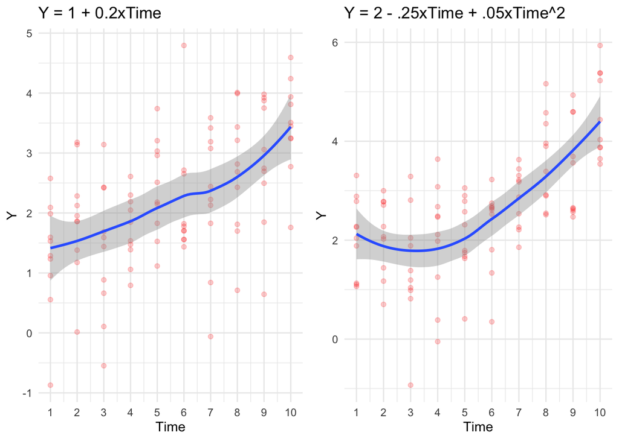

## 1.8 成長曲線モデル

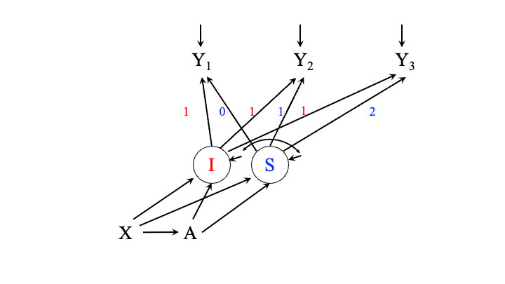

- どのような要因$A$が水準$I$や変化$S$に影響を与えるのか．

## 1.9 (2) 因果

- $A$を原因・処置・介入，$Y$を結果とする．
- $A$は独立変数，$Y$は従属変数と呼ばれることもある．
- 実験なら基本的には$A$と$Y$だけを考えればよいが，観察データでは$A$と$Y$以外にも様々な変数が関係してくる．

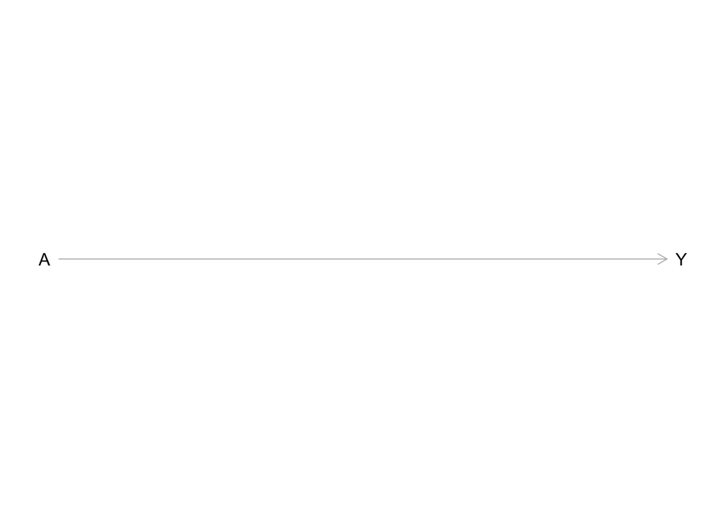

## 1.10 媒介

- $M$は$A$から$Y$への経路（パス）の途中にある媒介変数（mediator）．

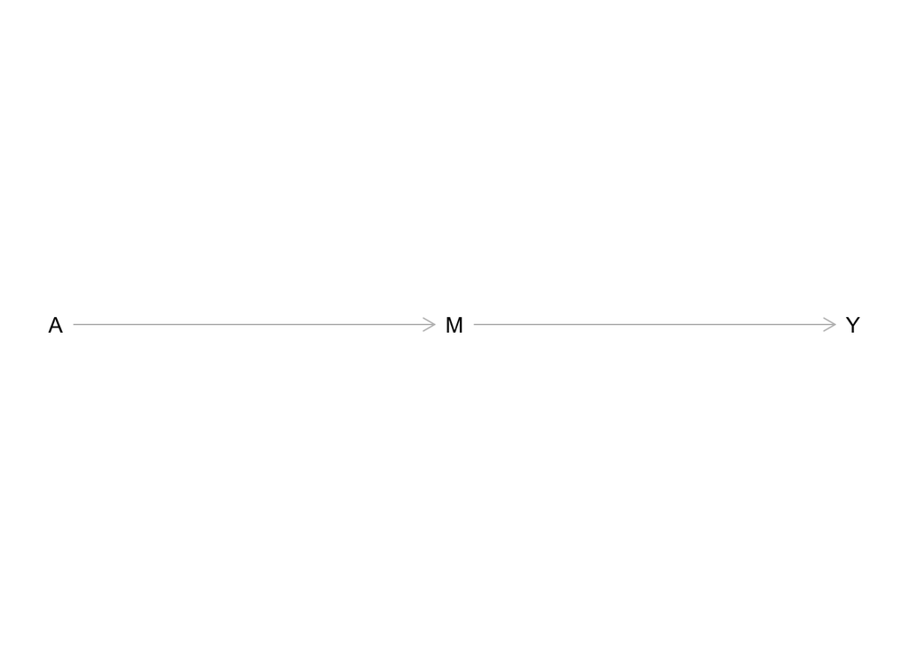

## 1.11 媒介変数は統制すべきか

- $Y$に対する$A$の効果を見たいとき，$M$は統制すべきではない．
- $M$を統制すると，$A$から$Y$への因果的経路が閉じてしまう．

$$A \rightarrow M \rightarrow Y$$

$$A \rightarrow \boxed{M} \rightarrow Y$$

## 1.12 交絡

- $Z$は$A$にも$Y$にも影響する交絡因子（confounders）．

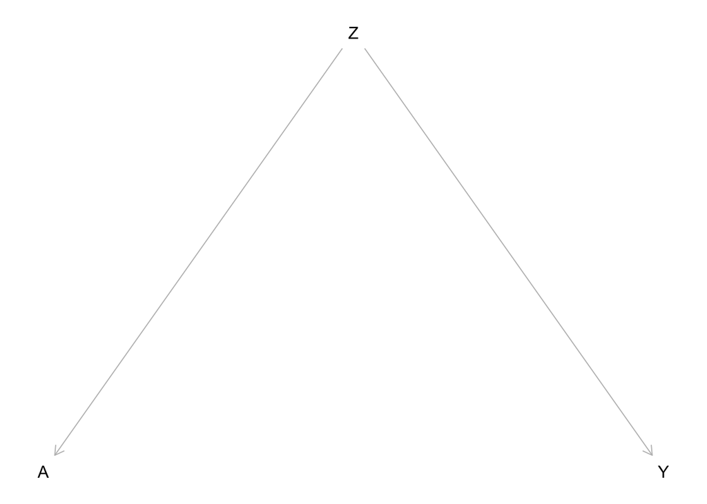

## 1.13 交絡変数は統制すべきか

- $Y$に対する$A$の効果を見たいとき，$Z$は統制すべき．
- $Z$を統制しないと，$A$から$Y$への非因果的経路が開いている．

$$A \leftarrow Z \rightarrow Y$$

$$A \leftarrow \boxed{Z} \rightarrow Y$$

## 1.14 合流点

- $C$は$A$と$Y$の結果となっている合流点（collider）．

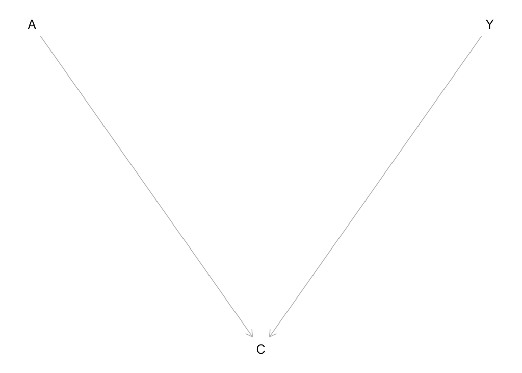

## 1.15 合流点変数は統制すべきか

- $Y$に対する$A$の効果を見たいとき，$C$は統制すべきではない．
- $C$を統制すると，$A$から$Y$への非因果的経路を開いてしまう．
  $$A \rightarrow C \leftarrow Y$$
  $$A \rightarrow \boxed{C} \leftarrow Y$$
- サンプルを限定した分析は注意が必要．
  - 大卒に限定した分析，既婚者に限定した分析，など

## 1.16 因果効果を求めるためには

- $Y$に対する$A$の効果を見たいときは何を統制すべきか．

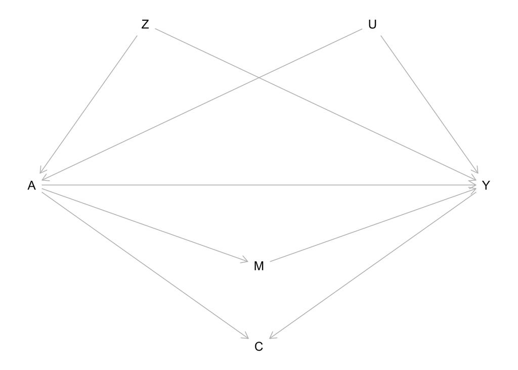

## 1.17 パスを書き出す

- すべての$A$から$Y$への経路（パス）を考える．
  $$A \leftarrow Z \rightarrow Y$$
  $$A \rightarrow M \rightarrow Y$$
  $$A \rightarrow C \leftarrow Y$$
  $$A \leftarrow U \rightarrow Y$$
  $$A \rightarrow Y$$
- $Z$と$U$を統制し，$M$や$C$を統制しない．

## 1.18 観察されない異質性

- $Z$は観察されるが，$U$が観察されない場合，$A$から$Y$への因果効果を求めようとしても，$A \leftarrow U \rightarrow Y$という非因果的経路が残ってしまい，バイアスを生じる．
- このような$U$は観察されない異質性（unobserved heterogeneity）と呼ばれる．
- いくら$Z$を統制しても$U$が考慮されなければ，因果効果については常に疑問が残る．
- 様々な方法で対応可能であり，パネルデータ分析はそのひとつ．

## 1.19 (3) メカニズム

- 理論的メカニズムを計量的に検証し，定量化．

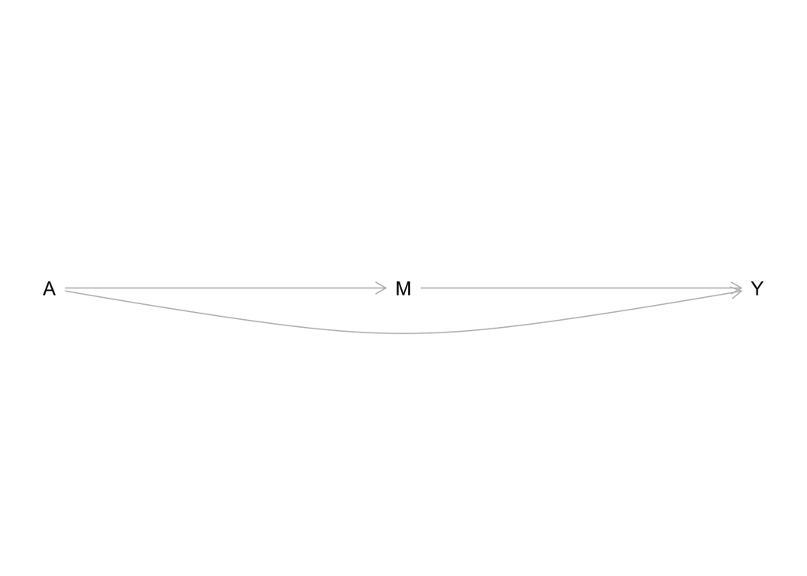

## 1.20 媒介分析

- $A$と$Y$の因果関係は，どの程度媒介変数$M$によって説明され，また説明されないのか．
- $M$を媒介としない$A$から$Y$への因果効果（直接効果），$M$を媒介とした$A$から$Y$への因果効果（間接効果）
- メカニズムや媒介を対象とする分析は基本的には因果関係の連鎖の枠組みで考える．
- パネルデータのような時間の情報は重要．

# 2 固定効果モデルによる因果分析

## 2.1 因果分析

- 固定効果モデルによる因果分析．
- パネルデータ分析の中で最も強力な方法．
- Allison (2009=2022) を読むことをおすすめ．

[figure not shown]

[figure not shown]

- パネルデータの構造を利用し，$U$を考慮して$A$から$Y$への因果効果を求める方法．

## 2.2 因果効果を求める際の問題

- $Z$は観察できるが，$U$のように観察できないようなもの（観察されない異質性）がある場合

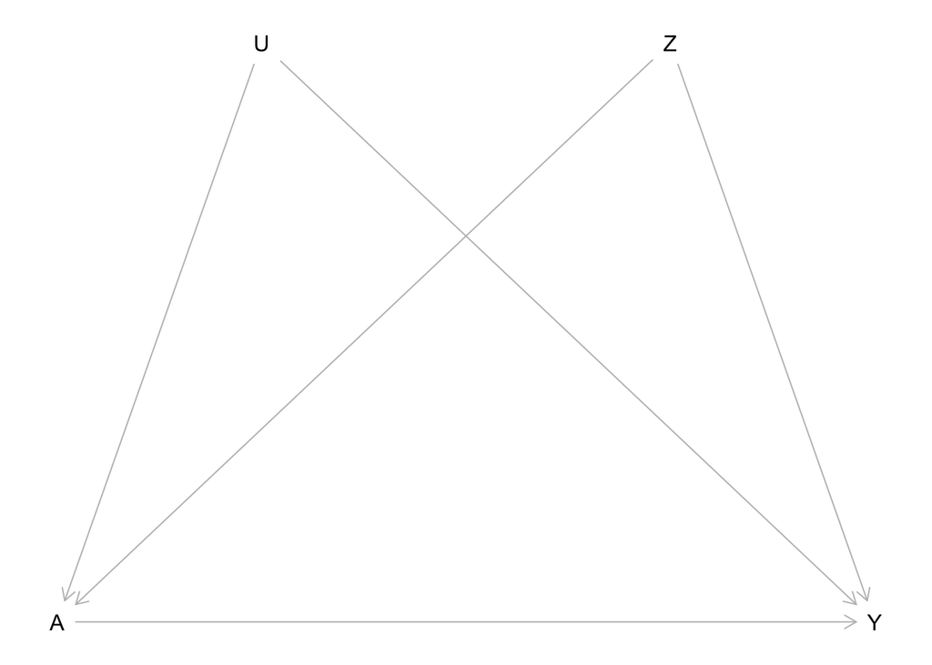

## 2.3 対応策

- 方法1：無作為割付（実験）
- 方法2：感度分析（sensitivity analysis）で，$U$のようなものがあっても因果効果が観察できるかをシミュレーション
- 方法3：操作変数（instrumental variable）を使用する．
- 方法4：$U$が時間とともに変化しないのであれば，パネルデータの固定効果モデルで分析

## 2.4 固定効果モデルを図示する

- 固定効果モデルの一般的な表記に合わせて処置を$X$，結果を$Y$，観察されない交絡要因を$U$とする．

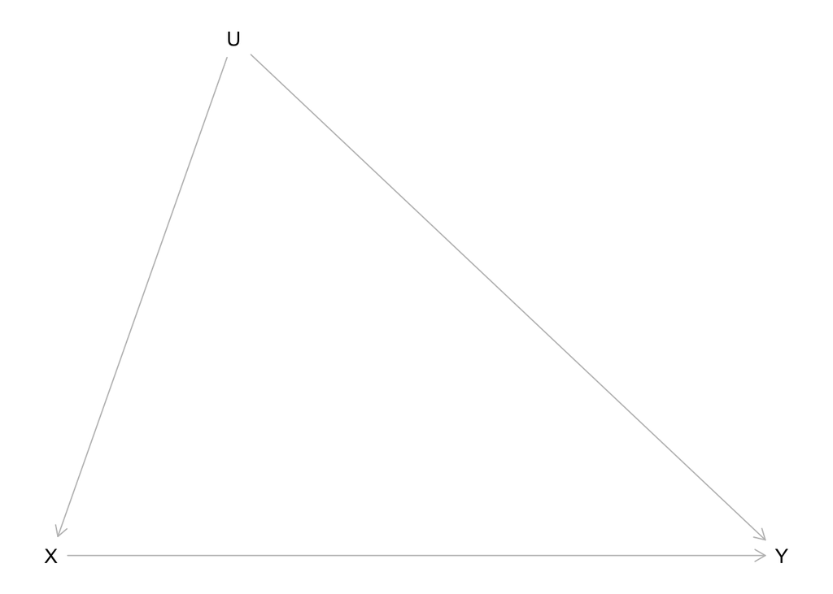

## 2.5 固定効果モデルを図示する

- 時点を考慮する．3時点であれば同様のDAGが3つ描ける．
- $U$は時点で変化しないので，添字はない．

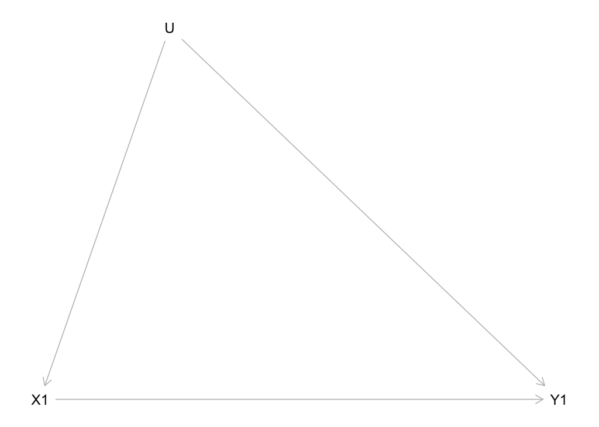

## 2.6 固定効果モデルを図示する

- 時間とともに変化する$Z_t$も考慮する．
- $U$は時間とともに変化しないので，$Z_t$に先行するものとして扱う．

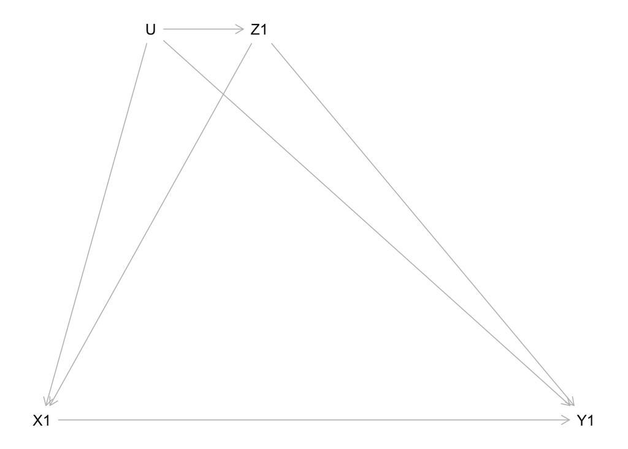

## 2.7 固定効果モデルを図示する

Imai and Kim (2019)

$$y_{it} = u_i + \beta x_{it} + \epsilon_{it}$$

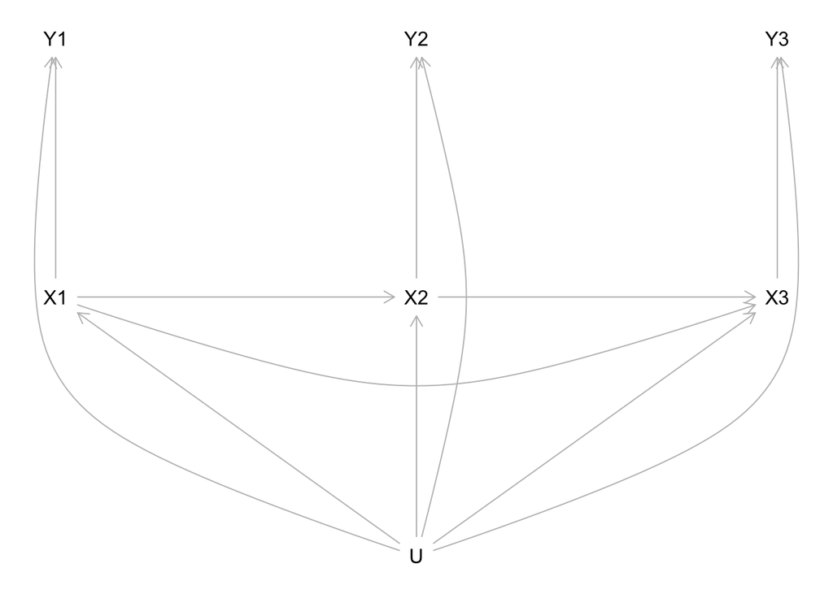

## 2.8 固定効果モデルを図示する

$Z_{it}$がある場合．

$$y_{it} = u_i + \beta x_{it} + \delta {\bf z}_{it} + \epsilon_{it}$$

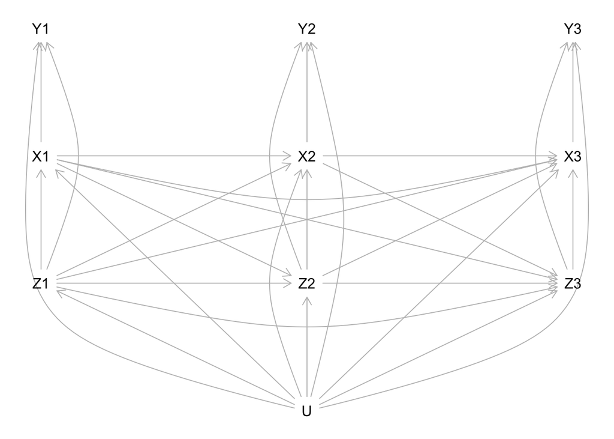

## 2.9 固定効果モデルを図示する

Bollen and Brand (2010)

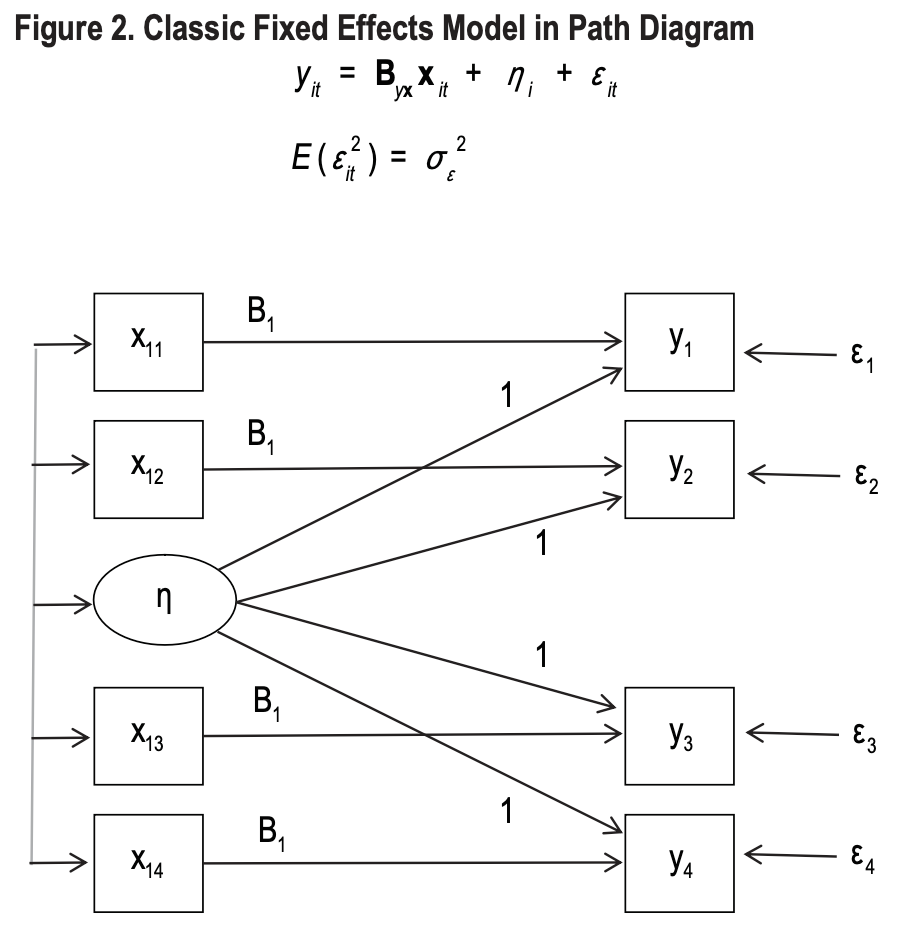

## 2.10 ランダム効果モデルを図示する

Bollen and Brand (2010)

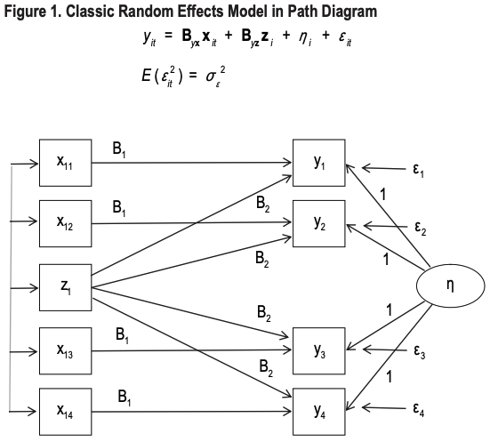

## 2.11 固定効果モデルの図示からみえてくるもの

Imai and Kim (2019); 大久保 (2021)

1. 時間で変化する未観測の交絡変数がない
2. 過去のアウトカムは現在のアウトカムに直接影響を与えない
3. 過去のアウトカムは現在の処置に直接影響を与えない
4. 過去の処置は現在のアウトカムに直接影響を与えない
- 固定効果モデルは広く使われているが，以上のような条件が満たされているかを確認することがあまり行われていない (大久保 2021)．

## 2.12 固定効果モデルによる推定

1. $u_i$をダミー変数として考える．
   $$y_{it} = u_i + \beta x_{it} + \epsilon_{it}$$
2. 全体平均をひいて，$u_i$を消す．
   $$y_{it} -{\bar y}_i = (u_i-u_i) + \beta (x_{it}-{\bar x}_{i}) + (\epsilon_{it}-{\bar \epsilon}_{i})$$
3. 一時点前のものをひいて，$u_i$を消す．
   $$y_{it}-y_{i,t-1} = (u_i-u_i) + \beta (x_{it}-x_{i,t-1}) + (\epsilon_{it}-\epsilon_{i,t-1})$$

## 2.13 パネルデータを用いた回帰分析

- Allison (2009); Vaisey and Miles (2017)

$$\begin{eqnarray}
y_{it} = \mu_t + \beta{\bf x_{it}} + \gamma{\bf z_{i}} + \alpha_i + \epsilon_{it}, \ \ \ i = 1, \dots, N, \ \ t = 1, \dots, T.
\end{eqnarray}$$

- $\mu_t$：時点によって変化する切片
- ${\bf x_{it}}$：時点によって変化する一連の予測変数
- ${\bf z_{i}}$：時点によって変化しない一連の予測変数
- $\alpha_i$：時点によって変化しない個人間で異なる誤差
- $\epsilon_{it}$：時点間・個人間で異なる誤差

## 2.14 固定効果とランダム効果

- $\alpha_i$をどのように扱い，${\bf x_{it}}$や${\bf z_{i}}$との間にどのような仮定を置くのかが，固定効果モデル（fixed effects model）とランダム効果モデル（random effects model）の違い．
- *RE models assume that the observed predictors in the model are not correlated with u while FE models allow them to be correlated* (Vaisey and Miles 2017, :47).

## 2.15 固定効果とランダム効果

- 固定効果モデルでは$\alpha_i$と$x_{it}$や$z_{i}$とは相関している．
- 固定効果モデルでは$\alpha_i$を固定された効果と考える．1000人いれば999個のダミー変数を用いて通常の線形重回帰モデルで分析し，時間とともに変化しない個体差を統制する．
- ランダム効果モデルでは$\alpha_i$と$x_{it}$や$z_{i}$は相関しないと仮定．この仮定が満たされれば，$x_{it}$の推定値はよいものとなるが，満たされることは理論的にも実践的にもない．
- パネルデータを用いたランダム効果モデルは因果効果の推定以外の別の目的に用いられるべきか．
- 応用研究においては，本来は併用して用いられるはずのないモデルが，なぜかともに用いられ，モデルの比較が行われている状況（例：ハウスマン検定）
- モデルの当てはまりよりも目的（記述 or 因果）を重視すべき

## 2.16 固定効果モデル

- 時間とともに変化する変数（$y_{it}$）に対する時間とともに変化する変数（$x_{it}$）の因果効果を求めたい場合，固定効果モデルは強力な道具．
- 時間とともに変化しない変数（$z_{i}$）は固定効果モデルでは分析から除かれてしまうため，その関連を推定できないことが欠点とされる．しかし，これを欠点と考えることは大きな間違い．
- そもそも$z_{i}$の係数にわれわれは興味がないはず．もし興味があるのであれば，別のモデルを考える必要がある．

## 2.17 固定効果モデルを用いる際の注意点

- 変化の情報を利用するため，$y_{it}$や${\bf x_{it}}$にも当然十分な変化が観察されなければならない．
- 因果効果を明確にしたければ，${\bf x_{it}}$の中での順序を整理し，モデルを組み立てる．
- 特に関心のある$x$と$y$の中間にある変数は入れるべきではない（$M$の条件付けに関するスライドを参照）．

## 2.18 因果効果に注目した固定効果モデル

- 一つの変数$x_{it}$の因果効果$\theta$に注目したモデル．
  $$y_{it} = \mu_t + \theta x_{it} + \beta {\bf z_{it}} + \gamma {\bf c_{i}}+ \alpha_i + \epsilon_{it}.$$
- $\mu_t$：時点によって変化する切片
- $x_{it}$：時点によって変化する処置変数
- ${\bf z_{it}}$：時点によって変化する一連の交絡変数
- ${\bf c_{i}}$：時点によって変化しない一連の予測変数
- $\alpha_i$：時点によって変化しない個人間で異なる誤差
- $\epsilon_{it}$：時点間・個人間で異なる誤差

## 2.19 因果効果の異質性

$$y_{it} = \mu_t + \theta_1 x_{it} + \theta_2 x_{it} c_{i} + \beta {\bf z_{it}} + \alpha_i + \epsilon_{it}.$$

- $x_{it}$（時点によって変化する処置変数）と$c_{i}$の交差項をモデルに含める．
- $c_{i}$は単体では含めない（消えてしまう）．

## 2.20 異質性を見る上での注意点

- 2つの時点によって変化する変数の交互作用は見ない．
- $c_{i}$は$x_{it}$の原因となる（少なくとも時間的には先行する）．
- 探索的な分析ではなく，理論的に異質な効果の可能性を検討し，分析でテストする．

## 2.21 まとめ

- 固定効果モデルは観察されない異質性を考慮した強力なモデル
- 十分な変化の情報が必要
- 通常の回帰分析と同様にデータ生成プロセスに注意
- 因果効果の異質性を明らかにすることも可能

# 3 JLPSデータを用いたパネルデータ分析

- パッケージをまとめて読み込む．

```r
pacman::p_load(tidyverse,  # データの整理
               haven,  # データの読み込み
               janitor,  # クロス集計
               lmtest,  # 標準誤差の調整
               sandwich,  # 標準誤差の調整
               estimatr,  # ロバスト回帰
               plm,  # パネルデータ分析
               fixest,  # 固定効果モデル
               modelsummary,  # 回帰分析の結果の整理
               gtsummary,   # 記述統計表を作成
               broom,  # 回帰分析の結果をみる
               labelled,  # ラベルの処理
               here
               )
```

## 3.1 JLPSデータの読みこみ

```r
PY110 <- read_dta(here("data","PY120","PY120.dta"))
PM110 <- read_dta(here("data","PM120","PM120.dta"))
JLPS <- bind_rows(PY110,PM110,.id = "YM")
JLPS
```

```
# A tibble: 4,800 × 6,026
   YM    PanelID BLOCK   SIZE    sex     ybirth mbirth ZQ02A   zq02ay48 zq02az48
   <chr>   <dbl> <dbl+l> <dbl+l> <dbl+l>  <dbl>  <dbl> <dbl+l> <dbl+lb> <dbl+lb>
 1 1           1 3 [関… 3 [そ… 1 [mal…   1981      2 1 [だ… 17        0
 2 1           2 3 [関… 3 [そ… 1 [mal…   1975      1 1 [だ…  7       20
 3 1           4 3 [関… 3 [そ… 2 [fem…   1985      5 1 [だ…  7        0
 4 1           5 3 [関… 3 [そ… 2 [fem…   1985     10 1 [だ…  8        0
 5 1           6 3 [関… 3 [そ… 2 [fem…   1977     10 1 [だ…  6        0
 6 1           7 3 [関… 3 [そ… 2 [fem…   1978      5 1 [だ…  7        0
 7 1           8 3 [関… 3 [そ… 2 [fem…   1976      9 1 [だ…  7       15
 8 1           9 3 [関… 3 [そ… 2 [fem…   1974      6 1 [だ…  6       30
 9 1          11 3 [関… 2 [20… 1 [mal…   1973     12 1 [だ…  7        0
10 1          14 3 [関… 2 [20… 2 [fem…   1978      5 1 [だ…  7       30
# ℹ 4,790 more rows
# ℹ 6,016 more variables: ZQ02B <dbl+lbl>, zq02by48 <dbl+lbl>,
#   zq02bz48 <dbl+lbl>, ZQ02C <dbl+lbl>, zq02cy48 <dbl+lbl>,
#   zq02cz48 <dbl+lbl>, ZQ02D <dbl+lbl>, zq02dy48 <dbl+lbl>,
#   zq02dz48 <dbl+lbl>, ZQ03 <dbl+lbl>, ZQ03_1 <dbl+lbl>, ZQ03_2 <dbl+lbl>,
#   ZQ03_3 <dbl+lbl>, JC_1 <dbl+lbl>, JC_2 <dbl+lbl>, JC_2L <dbl+lbl>,
#   JC_2C <dbl+lbl>, JC_2R <dbl+lbl>, JC_3 <dbl+lbl>, JC_41 <dbl+lbl>, …
```

## 3.2 ラベルを取り除く

- 不要であればラベルを取り除く．
- `zap_label`は変数ラベル（variable labels）を取り除く．
- `zap_labels`は値ラベル（value labels）を取り除く．

```r
JLPS <- JLPS |>
  zap_label() |>
  zap_labels()
```

## 3.3 ワイド形式のデータ

ここでは`satis_2007`，`satis_2008`のように`変数名_年`として分析に使用する変数を管理している．`_`は変数名に含まれていることも多いので，かわりに`__`を使うなどの工夫もできる．

```r
wide_d <- JLPS |>
  mutate(women = sex - 1,
         univ = case_when(ZQ23A %in% 1:4 ~ 0,
                          ZQ23A %in% 5:6 ~ 1,
                          TRUE ~ NA_real_),
         satis_2007 = ZQ30D,
         satis_2008 = AQ32D,
         satis_2009 = BQ23F,
         satis_2010 = CQ20F,
         marry_2007 = ZQ50,
         marry_2008 = AQ52,
         marry_2009 = BQ42,
         marry_2010 = CQ45,
         hincome_2007 = ZQ47C,
         hincome_2008 = AQ48C,
         hincome_2009 = BQ36C,
         hincome_2010 = CQ37C,
         ssm_2007 = JC_2C,
         ssm_2008 = aq03_2c,
         ssm_2009 = bq03_2c,
         ssm_2010 = cq03_2c,
         empstatus_2007 = JC_1,
         empstatus_2008 = AQ03_1,
         empstatus_2009 = BQ03_1,
         empstatus_2010 = CQ03_1,
         position_2007 = JC_3,
         position_2008 = BQ03_3,
         position_2009 = CQ03_3,
         position_2010 = DQ03_3,
         firmsize_2007 = JC_6,
         firmsize_2008 = AQ03_7,
         firmsize_2009 = BQ03_7,
         firmsize_2010 = CQ03_7
         ) |>
  dplyr::select(PanelID, women, univ,
                starts_with("satis_"),
                starts_with("marry_"),
                starts_with("hincome_"),
                starts_with("ssm_"),
                starts_with("empstatus_"),
                starts_with("position_"),
                starts_with("firmsize_"))
wide_d
```

```
# A tibble: 4,800 × 31
   PanelID women  univ satis_2007 satis_2008 satis_2009 satis_2010 marry_2007
     <dbl> <dbl> <dbl>      <dbl>      <dbl>      <dbl>      <dbl>      <dbl>
 1       1     0     0          3          3          3          3          1
 2       2     0     0          2          3          2          2          2
 3       4     1     0          1         NA         NA         NA          1
 4       5     1     1          1          1          1          1          1
 5       6     1     0          1          2          2          1          2
 6       7     1     0          2          3          2         NA          1
 7       8     1     1          4         NA         NA         NA          1
 8       9     1     0          1          2          2          2          2
 9      11     0     0          2          1         NA         NA          2
10      14     1     0          2          2         NA         NA          1
# ℹ 4,790 more rows
# ℹ 23 more variables: marry_2008 <dbl>, marry_2009 <dbl>, marry_2010 <dbl>,
#   hincome_2007 <dbl>, hincome_2008 <dbl>, hincome_2009 <dbl>,
#   hincome_2010 <dbl>, ssm_2007 <dbl>, ssm_2008 <dbl>, ssm_2009 <dbl>,
#   ssm_2010 <dbl>, empstatus_2007 <dbl>, empstatus_2008 <dbl>,
#   empstatus_2009 <dbl>, empstatus_2010 <dbl>, position_2007 <dbl>,
#   position_2008 <dbl>, position_2009 <dbl>, position_2010 <dbl>, …
```

## 3.4 ロング形式のデータ

```r
long_d <- wide_d |>
  tidyr::pivot_longer(cols = -c(PanelID,women,univ)) |>
  tidyr::separate(name, into = c("var", "year"), sep = "_") |>
  tidyr::pivot_wider(id_cols = c(PanelID,women,univ,year),
              names_from = var,
              values_from = value) |>
  mutate(year = as.numeric(year))
long_d
```

```
# A tibble: 19,200 × 11
   PanelID women  univ  year satis marry hincome   ssm empstatus position
     <dbl> <dbl> <dbl> <dbl> <dbl> <dbl>   <dbl> <dbl>     <dbl>    <dbl>
 1       1     0     0  2007     3     1       7   633         5        1
 2       1     0     0  2008     3     2       6   633         5        2
 3       1     0     0  2009     3     2       6   634         5        8
 4       1     0     0  2010     3     2       6   998        10        1
 5       2     0     0  2007     2     2       7   625         2        1
 6       2     0     0  2008     3     1       7   625         2        2
 7       2     0     0  2009     2     1       7   625         2        2
 8       2     0     0  2010     2     1       7   625         2        2
 9       4     1     0  2007     1     1       9   579        12        1
10       4     1     0  2008    NA    NA      NA    NA        NA       NA
# ℹ 19,190 more rows
# ℹ 1 more variable: firmsize <dbl>
```

- ロング形式のデータでまとめて複数時点の変数の加工を行う．

```r
# ssm職業翔分類のseiコードを取得
sei <- read.csv("https://raw.githubusercontent.com/ShoFujihara/OccupationalScales/master/SSM_sei_ssi_v1.0.csv") |>
  dplyr::select(ssm,sei)
head(sei)
```

```
  ssm      sei
1 501 68.01936
2 502 71.00038
3 503 64.23232
4 504 60.12396
5 505 62.24531
6 506 62.55008
```

```r
long_d <- long_d |>
  mutate(satis = case_when(satis %in% 1:5 ~ 5 - satis),
         marry = case_when(year == 2007 & marry %in% c(1,3,4) ~ 0,   # 2007だけ値が異なるので注意
                           year == 2007 & marry == 2 ~ 1,
                           !year == 2007 & marry %in% c(2,3,4) ~ 0,
                           !year == 2007 & marry == 1 ~ 1,
                           TRUE ~ NA_real_),
    hincome = case_when(hincome == 1 ~ 5,
                             hincome == 2 ~ 12.5,
                             hincome == 3 ~ 50,
                             hincome == 4 ~ 100,
                             hincome == 5 ~ 200,
                             hincome == 6 ~ 300,
                             hincome == 7 ~ 400,
                             hincome == 8 ~ 500,
                             hincome == 9 ~ 700,
                             hincome == 10 ~ 1000,
                             hincome == 11 ~ 1500,
                             hincome == 12 ~ 2000,
                             hincome == 13 ~ 2250,
                             hincome == 14 ~ NA_real_,
                             TRUE ~ NA_real_),
    log_hincome = log(hincome),
    # ssm小分類管理職修正
    r_ssm = case_when(!ssm <= 553 &
                      position %in% 4:6 &
                      firmsize %in% 9 ~ 545,  # 管理的公務員
                      !ssm <= 553 &
                      position %in% 4:5 &
                      firmsize %in% 7:8 ~ 550,  # 会社・団体等の管理職員
                      !ssm <= 553 &
                      (position == 6 | empstatus %in% c(1,6)) &
                      firmsize %in% 5:9 ~ 548,  # 会社役員
                    TRUE ~ ssm))
long_d
```

```
# A tibble: 19,200 × 13
   PanelID women  univ  year satis marry hincome   ssm empstatus position
     <dbl> <dbl> <dbl> <dbl> <dbl> <dbl>   <dbl> <dbl>     <dbl>    <dbl>
 1       1     0     0  2007     2     0     400   633         5        1
 2       1     0     0  2008     2     0     300   633         5        2
 3       1     0     0  2009     2     0     300   634         5        8
 4       1     0     0  2010     2     0     300   998        10        1
 5       2     0     0  2007     3     1     400   625         2        1
 6       2     0     0  2008     2     1     400   625         2        2
 7       2     0     0  2009     3     1     400   625         2        2
 8       2     0     0  2010     3     1     400   625         2        2
 9       4     1     0  2007     4     0     700   579        12        1
10       4     1     0  2008    NA    NA      NA    NA        NA       NA
# ℹ 19,190 more rows
# ℹ 3 more variables: firmsize <dbl>, log_hincome <dbl>, r_ssm <dbl>
```

```r
# 修正の確認
long_d |> filter(ssm != r_ssm) |>
  dplyr::select(ssm, r_ssm, empstatus, position, firmsize) |>
  unique() |>
  print(n = Inf)
```

```
# A tibble: 69 × 5
     ssm r_ssm empstatus position firmsize
   <dbl> <dbl>     <dbl>    <dbl>    <dbl>
 1   554   550         2        4        8
 2   559   550         2        4        8
 3   611   550         2        5        7
 4   611   550         2        5        8
 5   686   548         6        1        8
 6   686   548         6       NA        8
 7   557   550         2        4        7
 8   573   550         2        4        8
 9   573   550         2        4        7
10   685   548         4        6        8
11   574   550         2        4        8
12   554   550         2        5        8
```

[output cut: 57 more lines]

```r
# sei変数のマッチ
long_d <- long_d |>
  dplyr::left_join(sei, by = c("r_ssm" = "ssm"))
long_d |> dplyr::select(r_ssm,sei)
```

```
# A tibble: 19,200 × 2
   r_ssm   sei
   <dbl> <dbl>
 1   633  48.0
 2   633  48.0
 3   634  45.5
 4   998  NA
 5   625  44.2
 6   625  44.2
 7   625  44.2
 8   625  44.2
 9   579  44.8
10    NA  NA
# ℹ 19,190 more rows
```

## 3.5 ラグ付き変数

`group_by`と`dplyr::lag`を用いる．念の為に`arrange(PanelID, year)`で順番を整理しておく．

```r
long_d <- long_d |>
  arrange(PanelID, year) |>
  group_by(PanelID) |>
  mutate(lag_satis = dplyr::lag(satis),
         lag_marry = dplyr::lag(marry),
         lag_hincome =  dplyr::lag(hincome),
         lag_sei =  dplyr::lag(sei)) |>
  ungroup()
long_d
```

```
# A tibble: 19,200 × 18
   PanelID women  univ  year satis marry hincome   ssm empstatus position
     <dbl> <dbl> <dbl> <dbl> <dbl> <dbl>   <dbl> <dbl>     <dbl>    <dbl>
 1       1     0     0  2007     2     0     400   633         5        1
 2       1     0     0  2008     2     0     300   633         5        2
 3       1     0     0  2009     2     0     300   634         5        8
 4       1     0     0  2010     2     0     300   998        10        1
 5       2     0     0  2007     3     1     400   625         2        1
 6       2     0     0  2008     2     1     400   625         2        2
 7       2     0     0  2009     3     1     400   625         2        2
 8       2     0     0  2010     3     1     400   625         2        2
 9       3     0     1  2007     3     1      NA   802         2        3
10       3     0     1  2008     2     1     500   802         2       NA
# ℹ 19,190 more rows
# ℹ 8 more variables: firmsize <dbl>, log_hincome <dbl>, r_ssm <dbl>,
#   sei <dbl>, lag_satis <dbl>, lag_marry <dbl>, lag_hincome <dbl>,
#   lag_sei <dbl>
```

## 3.6 遷移行列

- 生活満足度についてラグ付き変数ともとの変数でクロス表を作成

```r
long_d |> tabyl(lag_satis, satis, show_na = FALSE)
```

```
 lag_satis   0   1    2    3   4
         0 109  84   86   44  11
         1  92 335  317  198  20
         2  77 330 1165  851 104
         3  30 159  793 3141 623
         4   6  15  119  689 836
```

- 行パーセントで示す．

```r
long_d |> tabyl(lag_satis, satis, show_na = FALSE) |>
  adorn_percentages("row") |>
  adorn_pct_formatting()
```

```
 lag_satis     0     1     2     3     4
         0 32.6% 25.1% 25.7% 13.2%  3.3%
         1  9.6% 34.8% 33.0% 20.6%  2.1%
         2  3.0% 13.1% 46.1% 33.7%  4.1%
         3  0.6%  3.4% 16.7% 66.2% 13.1%
         4  0.4%  0.9%  7.1% 41.4% 50.2%
```

- モザイクプロットで確認する

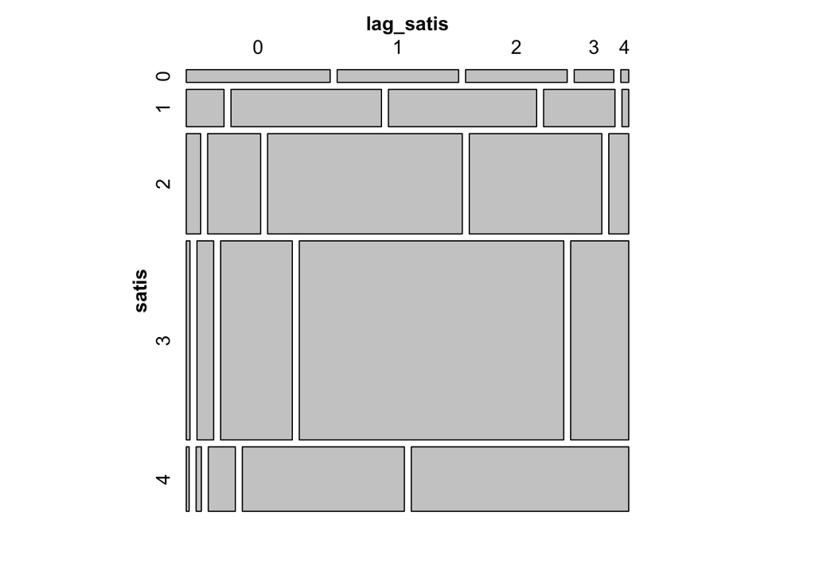

```r
long_d |> vcd::mosaic(~ satis + lag_satis, data = _)
```

- ggplotで処理する．

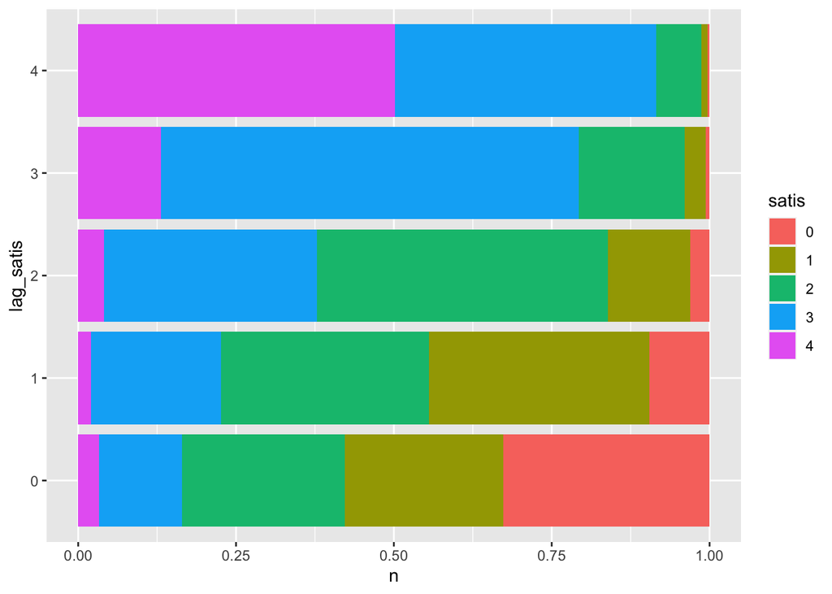

```r
long_d |>
  dplyr::count(lag_satis, satis) |>
  drop_na() |>
  mutate(across(c(lag_satis, satis), factor)) |>
  ggplot(aes(x = lag_satis, y = n, fill = satis)) +
  geom_col(position = "fill") +
  coord_flip()
```

- 婚姻状態についてラグ付き変数ともとの変数でクロス表を作成

```r
long_d |> tabyl(lag_marry, marry, show_na = FALSE)
```

```
 lag_marry    0    1
         0 4753  281
         1   47 5386
```

- 行パーセントで示す．

```r
long_d |> tabyl(lag_marry, marry, show_na = FALSE) |>
  adorn_percentages("row") |>
  adorn_pct_formatting()
```

```
 lag_marry     0     1
         0 94.4%  5.6%
         1  0.9% 99.1%
```

## 3.7 プールドOLS

- 通常の重回帰分析による結果．`lm`，`lm_robust`，`feols`関数を用いて行う．
- 標準誤差の調整は行っていない．

```r
pooled_1 <- lm(satis ~ marry, data = long_d)
summary(pooled_1)
```

```
Call:
lm(formula = satis ~ marry, data = long_d)

Residuals:
    Min      1Q  Median      3Q     Max
-2.8384 -0.3745  0.1616  0.6255  1.6255

Coefficients:
            Estimate Std. Error t value Pr(>|t|)
(Intercept)  2.37446    0.01106   214.7   <2e-16 ***
marry        0.46398    0.01531    30.3   <2e-16 ***
---
Signif. codes:  0 '***' 0.001 '**' 0.01 '*' 0.05 '.' 0.1 ' ' 1

Residual standard error: 0.9481 on 15359 degrees of freedom
  (3839 observations deleted due to missingness)
Multiple R-squared:  0.0564,    Adjusted R-squared:  0.05633
F-statistic: 917.9 on 1 and 15359 DF,  p-value: < 2.2e-16
```

```r
glance(pooled_1)
```

```
# A tibble: 1 × 12
  r.squared adj.r.squared sigma statistic   p.value    df  logLik    AIC    BIC
      <dbl>         <dbl> <dbl>     <dbl>     <dbl> <dbl>   <dbl>  <dbl>  <dbl>
1    0.0564        0.0563 0.948      918. 6.80e-196     1 -20977. 41960. 41983.
# ℹ 3 more variables: deviance <dbl>, df.residual <int>, nobs <int>
```

- 標準誤差の調整を行う．
- `lmtest`と`sandwich`パッケージが必要

```r
lmtest::coeftest(pooled_1, vcov = vcovCL, cluster = ~PanelID)
```

```
t test of coefficients:

            Estimate Std. Error t value  Pr(>|t|)
(Intercept) 2.374456   0.017553 135.275 < 2.2e-16 ***
marry       0.463976   0.022982  20.188 < 2.2e-16 ***
---
Signif. codes:  0 '***' 0.001 '**' 0.01 '*' 0.05 '.' 0.1 ' ' 1
```

- `lm_robust`を使用する場合は直接クラスタを指定可能．

```r
pooled_2 <- lm_robust(satis ~ marry, cluster = PanelID, data = long_d)
summary(pooled_2)
```

```
Call:
lm_robust(formula = satis ~ marry, data = long_d, clusters = PanelID)

Standard error type:  CR2

Coefficients:
            Estimate Std. Error t value  Pr(>|t|) CI Lower CI Upper   DF
(Intercept)    2.374    0.01755  135.26 0.000e+00   2.3400    2.409 2200
marry          0.464    0.02298   20.19 1.238e-86   0.4189    0.509 4281

Multiple R-squared:  0.0564 ,   Adjusted R-squared:  0.05633
F-statistic: 407.5 on 1 and 4793 DF,  p-value: < 2.2e-16
```

```r
glance(pooled_2)
```

```
   r.squared adj.r.squared statistic      p.value df.residual  nobs se_type
1 0.05639545    0.05633401  407.4891 4.890198e-87    2200.348 15361     CR2
```

- `feols`を使用する場合も直接クラスタを指定可能．

```r
pooled_3 <- feols(satis ~ marry, cluster = "PanelID",  data = long_d)
summary(pooled_3)
```

```
OLS estimation, Dep. Var.: satis
Observations: 15,361
Standard-errors: Clustered (PanelID)
            Estimate Std. Error  t value  Pr(>|t|)
(Intercept) 2.374456   0.017553 135.2750 < 2.2e-16 ***
marry       0.463976   0.022982  20.1884 < 2.2e-16 ***
---
Signif. codes:  0 '***' 0.001 '**' 0.01 '*' 0.05 '.' 0.1 ' ' 1
RMSE: 0.948071   Adj. R2: 0.056334
```

```r
glance(pooled_3)
```

```
# A tibble: 1 × 9
  r.squared adj.r.squared within.r.squared pseudo.r.squared sigma  nobs    AIC
      <dbl>         <dbl>            <dbl>            <dbl> <dbl> <int>  <dbl>
1    0.0564        0.0563               NA               NA 0.948 15361 41958.
# ℹ 2 more variables: BIC <dbl>, logLik <dbl>
```

## 3.8 固定効果モデル

- Stataに比べ，Rでは時間がかかる（`plm`）．
- クラスタロバスト標準誤差を用いてない

```r
fixed_plm <- plm(satis ~ marry, data = long_d,
              index = c("PanelID", "year"),
              effect = "twoways",
              model = "within")
summary(fixed_plm)
```

```
Twoways effects Within Model

Call:
plm(formula = satis ~ marry, data = long_d, effect = "twoways",
    model = "within", index = c("PanelID", "year"))

Unbalanced Panel: n = 4794, T = 1-4, N = 15361

Residuals:
       Min.     1st Qu.      Median     3rd Qu.        Max.
-3.0665e+00 -2.4992e-01  7.7287e-05  2.8459e-01  2.6798e+00

Coefficients:
      Estimate Std. Error t-value  Pr(>|t|)
marry 0.278179   0.039743  6.9995 2.724e-12 ***
---
Signif. codes:  0 '***' 0.001 '**' 0.01 '*' 0.05 '.' 0.1 ' ' 1

Total Sum of Squares:    4437.5
Residual Sum of Squares: 4417
R-Squared:      0.0046168
Adj. R-Squared: -0.44742
F-statistic: 48.9932 on 1 and 10563 DF, p-value: 2.7244e-12
```

```r
glance(fixed_plm)
```

```
# A tibble: 1 × 7
  r.squared adj.r.squared statistic  p.value deviance df.residual  nobs
      <dbl>         <dbl>     <dbl>    <dbl>    <dbl>       <dbl> <int>
1   0.00462        -0.447      49.0 2.72e-12    4417.       10563 15361
```

- `feols`はかなり推定が早い．
- クラスタロバスト標準誤差

```r
fixed_feols <- feols(satis ~ marry | PanelID + year, data = long_d)
summary(fixed_feols)
```

```
OLS estimation, Dep. Var.: satis
Observations: 15,361
Fixed-effects: PanelID: 4,794,  year: 4
Standard-errors: Clustered (PanelID)
      Estimate Std. Error t value   Pr(>|t|)
marry 0.278179   0.048002 5.79521 7.2601e-09 ***
---
Signif. codes:  0 '***' 0.001 '**' 0.01 '*' 0.05 '.' 0.1 ' ' 1
RMSE: 0.536236     Adj. R2: 0.561041
                 Within R2: 0.004617
```

```r
glance(fixed_feols)
```

```
# A tibble: 1 × 9
  r.squared adj.r.squared within.r.squared pseudo.r.squared sigma  nobs    AIC
      <dbl>         <dbl>            <dbl>            <dbl> <dbl> <int>  <dbl>
1     0.698         0.561          0.00462               NA 0.647 15361 34043.
# ℹ 2 more variables: BIC <dbl>, logLik <dbl>
```

- `year`については`factor(year)`として直接推定しても良い．
- 結果は同じ．

```r
fixed_feols_t <- feols(satis ~ marry + factor(year) | PanelID, data = long_d)
summary(fixed_feols_t)
```

```
OLS estimation, Dep. Var.: satis
Observations: 15,361
Fixed-effects: PanelID: 4,794
Standard-errors: Clustered (PanelID)
                  Estimate Std. Error   t value   Pr(>|t|)
marry             0.278179   0.048002  5.795210 7.2601e-09 ***
factor(year)2008 -0.040147   0.014446 -2.779154 5.4713e-03 **
factor(year)2009  0.079644   0.015770  5.050208 4.5770e-07 ***
factor(year)2010  0.013062   0.016806  0.777263 4.3704e-01
---
Signif. codes:  0 '***' 0.001 '**' 0.01 '*' 0.05 '.' 0.1 ' ' 1
RMSE: 0.536236     Adj. R2: 0.561041
                 Within R2: 0.011479
```

## 3.9 ランダム効果モデル

- やり方だけ説明．

```r
random_plm  <- plm(satis ~ marry, data = long_d,
              model = "random",
              index = c("PanelID", "year"),
              )
summary(random_plm)
```

```
Oneway (individual) effect Random Effect Model
   (Swamy-Arora's transformation)

Call:
plm(formula = satis ~ marry, data = long_d, model = "random",
    index = c("PanelID", "year"))

Unbalanced Panel: n = 4794, T = 1-4, N = 15361

Effects:
                 var std.dev share
idiosyncratic 0.4205  0.6485 0.468
individual    0.4781  0.6915 0.532
theta:
   Min. 1st Qu.  Median    Mean 3rd Qu.    Max.
 0.3159  0.5239  0.5754  0.5476  0.5754  0.5754

Residuals:
    Min.  1st Qu.   Median     Mean  3rd Qu.     Max.
-2.98012 -0.34341  0.08115  0.00277  0.42212  1.96411

Coefficients:
            Estimate Std. Error z-value  Pr(>|z|)
(Intercept) 2.382931   0.015443 154.306 < 2.2e-16 ***
marry       0.425926   0.020368  20.911 < 2.2e-16 ***
---
Signif. codes:  0 '***' 0.001 '**' 0.01 '*' 0.05 '.' 0.1 ' ' 1

Total Sum of Squares:    6913.3
Residual Sum of Squares: 6513.3
R-Squared:      0.058605
Adj. R-Squared: 0.058544
Chisq: 437.272 on 1 DF, p-value: < 2.22e-16
```

## 3.10 モデルを比較

```r
msummary(list(pooled_3, fixed_feols, random_plm),
    stars=TRUE)
```

|  | (1) | (2) | (3) |
| --- | --- | --- | --- |
| (Intercept) | 2.374*** |  | 2.383*** |
|  | (0.018) |  | (0.015) |
| marry | 0.464*** | 0.278*** | 0.426*** |
|  | (0.023) | (0.048) | (0.020) |
| Num.Obs. | 15361 | 15361 | 15361 |
| R2 | 0.056 | 0.698 | 0.059 |
| R2 Adj. | 0.056 | 0.561 | 0.059 |
| R2 Within |  | 0.005 |  |
| R2 Within Adj. |  | 0.005 |  |
| AIC | 41958.3 | 34043.3 | 30419.1 |
| BIC | 41973.6 | 70698.0 | 30442.1 |
| RMSE | 0.95 | 0.54 | 0.65 |
| Std.Errors | by: PanelID | by: PanelID |  |
| FE: PanelID |  | X |  |
| FE: year |  | X |  |

+ p < 0.1, * p < 0.05, ** p < 0.01, *** p < 0.001

## 3.11 Hausman検定

```r
phtest(fixed_plm, random_plm, effect = "twoways")
```

```
    Hausman Test

data:  satis ~ marry
chisq = 18.744, df = 1, p-value = 1.495e-05
alternative hypothesis: one model is inconsistent
```

## 3.12 交互作用

- 時間とともに変化する変数と時間とともに変化しない変数の交互作用．
- `*`を使ってもよいが，時間とともに変化しない変数は自動的に削除されるためそれを含めず，`:`で交互作用項を追加する．
- 女性か否かと結婚

```r
fixed_feols_int_women <- feols(satis ~ marry + marry:women | PanelID + year,
                         data = long_d)
summary(fixed_feols_int_women)
```

```
OLS estimation, Dep. Var.: satis
Observations: 15,361
Fixed-effects: PanelID: 4,794,  year: 4
Standard-errors: Clustered (PanelID)
            Estimate Std. Error  t value   Pr(>|t|)
marry       0.276323   0.070499 3.919519 8.9963e-05 ***
marry:women 0.003112   0.094696 0.032864 9.7378e-01
---
Signif. codes:  0 '***' 0.001 '**' 0.01 '*' 0.05 '.' 0.1 ' ' 1
RMSE: 0.536236     Adj. R2: 0.560999
                 Within R2: 0.004617
```

- 自分で交互作用項を作成してもよい．

```r
fixed_feols_int_women <- long_d |>
  mutate(marryXwomen = marry*women) |>
  feols(satis ~ marry + marryXwomen | PanelID + year,
                         data = _)
summary(fixed_feols_int_women)
```

```
OLS estimation, Dep. Var.: satis
Observations: 15,361
Fixed-effects: PanelID: 4,794,  year: 4
Standard-errors: Clustered (PanelID)
            Estimate Std. Error  t value   Pr(>|t|)
marry       0.276323   0.070499 3.919519 8.9963e-05 ***
marryXwomen 0.003112   0.094696 0.032864 9.7378e-01
---
Signif. codes:  0 '***' 0.001 '**' 0.01 '*' 0.05 '.' 0.1 ' ' 1
RMSE: 0.536236     Adj. R2: 0.560999
                 Within R2: 0.004617
```

## 3.13 交互作用

- 大学卒か否かと結婚

```r
fixed_feols_int_univ <- feols(satis ~ marry + marry:univ | PanelID + year,
                       data = long_d)
summary(fixed_feols_int_univ)
```

```
OLS estimation, Dep. Var.: satis
Observations: 15,332
Fixed-effects: PanelID: 4,781,  year: 4
Standard-errors: Clustered (PanelID)
           Estimate Std. Error  t value   Pr(>|t|)
marry      0.270428   0.063098 4.285868 1.8561e-05 ***
marry:univ 0.019680   0.095381 0.206328 8.3654e-01
---
Signif. codes:  0 '***' 0.001 '**' 0.01 '*' 0.05 '.' 0.1 ' ' 1
RMSE: 0.536425     Adj. R2: 0.560892
                 Within R2: 0.004633
```

## 3.14 Stataのプログラム

この結果はstataで以下のようなプログラムを実行した場合と同じ結果である

```r
* Preparation
destring year, replace
xtset PanelID year

* Pooled OLS
reg satis marry, vce(cluster PanelID)

* Fixed effect
xtreg satis marry i.year, fe
xtreg satis marry i.year, fe vce(cluster PanelID)

* Random effect
xtreg satis marry i.year, re
```

## 3.15 時間とともに変化する共変量

- 世帯年収の変数を追加し統制する．
- ただし婚姻状態との因果関係はよく考える必要があるので注意が必要．
- 固定効果モデルによって観察されない異質性を考慮した上で予測力のある変数を探したいのか，それとも因果効果を明らかにしたいのかを分けて考える必要がある．目的によって変数の選択方法が異なる．

## 3.16 共変量を含めた固定効果モデル

```r
fixed_feols_2 <- feols(satis ~ marry + log(hincome) | PanelID + year,
               data = long_d)
summary(fixed_feols_2)
```

```
OLS estimation, Dep. Var.: satis
Observations: 10,809
Fixed-effects: PanelID: 4,098,  year: 4
Standard-errors: Clustered (PanelID)
             Estimate Std. Error t value   Pr(>|t|)
marry        0.326738   0.056214 5.81240 6.6270e-09 ***
log(hincome) 0.090955   0.025773 3.52915 4.2148e-04 ***
---
Signif. codes:  0 '***' 0.001 '**' 0.01 '*' 0.05 '.' 0.1 ' ' 1
RMSE: 0.494066     Adj. R2: 0.578947
                 Within R2: 0.009411
```

## 3.17 複数のモデルの比較

- ただし何のために複数のモデルが必要なのかはよく考える必要がある．
- モデルを比較するために`drop_na`で欠損値を除き，ケースをそろえる

```r
model_1 <- long_d |> drop_na(satis,marry,hincome) |>
  feols(satis ~ marry | PanelID + year, data = _)
model_2 <- long_d |> drop_na(satis,marry,hincome) |>
  feols(satis ~ marry + log(hincome) | PanelID + year, data = _)
```

## 3.18 複数のモデルの比較

```r
summary(model_1)
```

```
OLS estimation, Dep. Var.: satis
Observations: 10,809
Fixed-effects: PanelID: 4,098,  year: 4
Standard-errors: Clustered (PanelID)
      Estimate Std. Error t value   Pr(>|t|)
marry 0.333138   0.056521 5.89403 4.0722e-09 ***
---
Signif. codes:  0 '***' 0.001 '**' 0.01 '*' 0.05 '.' 0.1 ' ' 1
RMSE: 0.494706     Adj. R2: 0.577918
                 Within R2: 0.006841
```

```r
summary(model_2)
```

```
OLS estimation, Dep. Var.: satis
Observations: 10,809
Fixed-effects: PanelID: 4,098,  year: 4
Standard-errors: Clustered (PanelID)
             Estimate Std. Error t value   Pr(>|t|)
marry        0.326738   0.056214 5.81240 6.6270e-09 ***
log(hincome) 0.090955   0.025773 3.52915 4.2148e-04 ***
---
Signif. codes:  0 '***' 0.001 '**' 0.01 '*' 0.05 '.' 0.1 ' ' 1
RMSE: 0.494066     Adj. R2: 0.578947
                 Within R2: 0.009411
```

## 3.19 結果を表で表示

```r
msummary(list(model_1, model_2),
    stars=TRUE)
```

|  | (1) | (2) |
| --- | --- | --- |
| marry | 0.333*** | 0.327*** |
|  | (0.057) | (0.056) |
| log(hincome) |  | 0.091*** |
|  |  | (0.026) |
| Num.Obs. | 10809 | 10809 |
| R2 | 0.738 | 0.739 |
| R2 Adj. | 0.578 | 0.579 |
| R2 Within | 0.007 | 0.009 |
| R2 Within Adj. | 0.007 | 0.009 |
| AIC | 23664.1 | 23638.0 |
| BIC | 53560.0 | 53541.3 |
| RMSE | 0.49 | 0.49 |
| Std.Errors | by: PanelID | by: PanelID |
| FE: PanelID | X | X |
| FE: year | X | X |

+ p < 0.1, * p < 0.05, ** p < 0.01, *** p < 0.001

## 3.20 ハイブリッドモデル

- Hybrid model (Allison 2009)
- Correlated random effects model (Wooldridge 2019) とも呼ばれる．

$$y_{it} = \mu_t + \beta_{W} \left(x_{it} - {\bar x}_{i}\right) + \beta_{B}{\bar x}_{i} + \gamma{\bf z_{i}} + \alpha_i + \epsilon_{it}$$

## 3.21 ハイブリッドモデル

- グループ平均 $({\bar x}_{i})$とグループ平均からの偏差 $(x_{it} - {\bar x}_{i})$の両方をランダム効果モデルに用いる
- バランスされたデータ（balanced data）であれば，固定効果モデルの係数とランダム効果モデルの$(x_{it} - {\bar x}_{i})$の係数$\beta_{W}$（個体内効果：within-effect）は一致する．

## 3.22 ハイブリッドモデル

- グループ平均は`group_by`を使って作成．
- 最後に`ungroup()`を忘れないようにする．

```r
long_d <- long_d |>
  group_by(PanelID) |>
  mutate(marry_mn = mean(marry, na.rm = TRUE),
         marry_dev = marry - marry_mn) |>
  ungroup()
long_d |> print(n = 300)
```

```
# A tibble: 19,200 × 20
    PanelID women  univ  year satis marry hincome   ssm empstatus position
      <dbl> <dbl> <dbl> <dbl> <dbl> <dbl>   <dbl> <dbl>     <dbl>    <dbl>
  1       1     0     0  2007     2     0     400   633         5        1
  2       1     0     0  2008     2     0     300   633         5        2
  3       1     0     0  2009     2     0     300   634         5        8
  4       1     0     0  2010     2     0     300   998        10        1
  5       2     0     0  2007     3     1     400   625         2        1
  6       2     0     0  2008     2     1     400   625         2        2
  7       2     0     0  2009     3     1     400   625         2        2
  8       2     0     0  2010     3     1     400   625         2        2
  9       3     0     1  2007     3     1      NA   802         2        3
 10       3     0     1  2008     2     1     500   802         2       NA
 11       3     0     1  2009    NA    NA      NA    NA        NA       NA
 12       3     0     1  2010    NA    NA      NA    NA        NA        3
```

[output cut: 292 more lines]

## 3.23 ハイブリッドモデル

- グループ平均からの偏差`marry_dev`とグループ平均`marry_mn`の両方をモデルに含める．

```r
hybrid_plm  <- plm(satis ~ marry_dev + marry_mn,
                   data = long_d,
                   model = "random",
                   index = c("PanelID", "year"),
                   effect = "twoways")
```

## 3.24 モデルの比較

- ハイブリッドモデルの係数が固定効果モデルのものと近い（一致はしない）ことを確認．
- `marry_mn`の係数は個体間効果（between-effect）である．ただし，この変数の解釈は難しい．

```r
msummary(list("Hybrid" = hybrid_plm,
              "Fixed" = fixed_plm,
              "Random" = random_plm),
         coef_rename = c('marry_dev'='marry'),
         stars = TRUE)
```

|  | Hybrid | Fixed | Random |
| --- | --- | --- | --- |
| (Intercept) | 2.365*** |  | 2.383*** |
|  | (0.054) |  | (0.015) |
| marry | 0.271*** | 0.278*** | 0.426*** |
|  | (0.061) | (0.040) | (0.020) |
| marry_mn | 0.470*** |  |  |
|  | (0.037) |  |  |
| Num.Obs. | 15361 | 15361 | 15361 |
| R2 | 0.057 | 0.005 | 0.059 |
| R2 Adj. | 0.057 | −0.447 | 0.059 |
| AIC | 41953.3 | 24451.3 | 30419.1 |
| BIC | 41983.9 | 24466.5 | 30442.1 |
| RMSE | 0.95 | 0.54 | 0.65 |

+ p < 0.1, * p < 0.05, ** p < 0.01, *** p < 0.001

## 3.25 ラグ付き従属変数モデル

- Lagged Dependent Variable (LDV)
- ラグ付きの従属変数$y_{i,t-1}$が観察されない個人間の異質性の代理指標となる (Vaisey and Miles 2017)

$$y_{it} = \mu + \rho y_{i,t-1} + {\bf x^\prime_{it}}\beta + {\bf z^\prime_{i}}\gamma + \epsilon_{it}$$

## 3.26 モデルの比較

- Vaisey and Miles (2017)

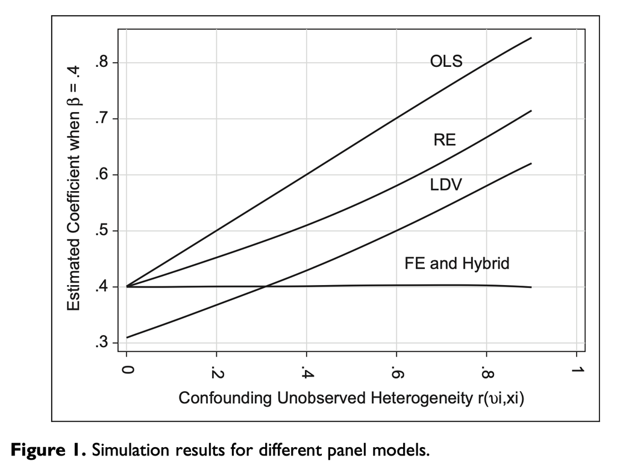

## 3.27 カテゴリカル変数がアウトカムの場合

- まず無理はせず，線形モデルで検討する．
- 必要であれば`feglm`などを使用する．

# 4 課題

## 4.1 研究計画を立てよう

- JLPSを用いた因果分析．
- 時間とともに変化する独立変数と従属変数を考える．
  - 従属変数は連続か2値がよい．
- 時間とともに変化する共変量を考える．
  - 媒介変数を含めないようにする．
  - DAGをもとにDGPを考える．
- シンプルな分析でよい．

## 4.2 パネルデータで何をしたいか

- 因果分析に活用する
- 変化を直接の関心とする

## References

Allison, Paul David. 2009. *Fixed Effects Regression Models*. Quantitative Applications in the Social Sciences 160. Los Angeles: SAGE.

Bollen, Kenneth A., and Jennie E. Brand. 2010. “A General Panel Model with Random and Fixed Effects: A Structural Equations Approach.” *Social Forces* 89 (1): 1–34. https://doi.org/10.1353/sof.2010.0072.

Imai, Kosuke, and In Song Kim. 2019. “When Should We Use Unit Fixed Effects Regression Models for Causal Inference with Longitudinal Data?” *American Journal of Political Science* 63 (2): 467–90. https://doi.org/10.1111/ajps.12417.

Vaisey, Stephen, and Andrew Miles. 2017. “What You Canand Can’tDo With Three-Wave Panel Data.” *Sociological Methods & Research* 46 (1): 44–67. https://doi.org/10.1177/0049124114547769.

Wooldridge, Jeffrey M. 2019. *Introductory Econometrics: A Modern Approach*. 7th edition. Boston, MA: South-Western Pub.

大久保将貴. 2021. “パネルデータ分析における固定効果モデルの取扱説明書.” *社会科学研究* 72 (2): 55–68.